# Week 13

## Quizz

1. Write code to create an array with colored stripes [red, yellow,green,cyan,blue].
2. Why might an array of RGB colors look washed out (too light) when displaying using imshow?
3. Write a function that takes a string (e.g. DG14) as input and separates the letters and numbers into a tuple (e.g. (DG,14)).

#### Answers

1.

```python
height = 5
width = 5
import numpy as np
stripes = np.zeros((height,width,3))
stripes[:,:2,0] = 1
stripes[:,1:4,1] = 1
stripes[:,3:,2] = 1
```

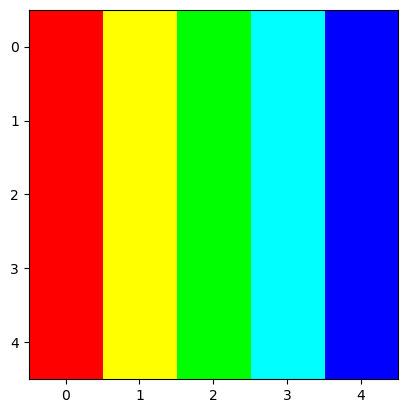

```python
import matplotlib.pyplot as plt
plt.imshow(stripes)
plt.show()
```

1. If we are using RGB color coordinates as integers between 0 and 255, we need to divide by 255 before plotting.

```python
def separate_nums(string):
    num=''
    let=''
    for char in string:
        if char.isdigit():
            num += char
        else:
            let += char
    return (let,int(num))
```

```python
separate_nums('DG14')
```

```
('DG', 14)
```

## Notes

### Encryption/decryption

To encrypt a message using the shift cipher, we need

- the message
- the shift value
- the alphabet

```python
def shift_cipher(message,shift,alphabet):
    encrypted_message = ''
    for char in message:
        index = alphabet.find(char)    #gives us the index
        new_index = (index+shift)%len(alphabet)
        new_char = alphabet[new_index]
        encrypted_message += new_char
    return encrypted_message
```

```python
message = 'HELLO MY NAME IS GRIZBORD BLIPBLOP'
alphabet = 'ABCDEFGHIJKLMNOPQRSTUVWXYZ '
encrypted = shift_cipher(message,13,alphabet)
encrypted
```

```
'URYYAMZKM NZRMVEMTDVLOADQMOYVBOYAB'
```

**Exercise:** Build a decryption function assuming you know all the required information.

```python
shift_cipher(encrypted,-13,alphabet)
```

[output not shown]

**Exercise:** Build a decryption function assuming you only know the encrypted message and alphabet.

Strategy:

1. Try all possible shifts. Infinitely many??
   - There are only 27 distinct shift values.
2. Check each message to see if it contains English words.
   - We need a list of English words from a dictionary.
   - Create a list of words for each message.
   - Check if each word is in the dictionary.
   - Determine if the message has been decrypted.

```python
encrypted = 'URYYAMZKM NZRMVEMTDVLOADQMOYVBOYAB'
```

```python
for shift in range(27):
    print((shift,shift_cipher(encrypted,-shift,alphabet)))
```

```
(0, 'URYYAMZKM NZRMVEMTDVLOADQMOYVBOYAB')
(1, 'TQXX LYJLZMYQLUDLSCUKN CPLNXUANX A')
(2, 'SPWWZKXIKYLXPKTCKRBTJMZBOKMWT MWZ ')
(3, 'ROVVYJWHJXKWOJSBJQASILYANJLVSZLVYZ')
(4, 'QNUUXIVGIWJVNIRAIP RHKX MIKURYKUXY')
(5, 'PMTTWHUFHVIUMHQ HOZQGJWZLHJTQXJTWX')
(6, 'OLSSVGTEGUHTLGPZGNYPFIVYKGISPWISVW')
(7, 'NKRRUFSDFTGSKFOYFMXOEHUXJFHROVHRUV')
(8, 'MJQQTERCESFRJENXELWNDGTWIEGQNUGQTU')
(9, 'LIPPSDQBDREQIDMWDKVMCFSVHDFPMTFPST')
(10, 'KHOORCPACQDPHCLVCJULBERUGCEOLSEORS')
(11, 'JGNNQBO BPCOGBKUBITKADQTFBDNKRDNQR')
(12, 'IFMMPANZAOBNFAJTAHSJ CPSEACMJQCMPQ')
(13, 'HELLO MY NAME IS GRIZBORD BLIPBLOP')
(14, 'GDKKNZLXZM LDZHRZFQHYANQCZAKHOAKNO')
(15, 'FCJJMYKWYLZKCYGQYEPGX MPBY JGN JMN')
(16, 'EBIILXJVXKYJBXFPXDOFWZLOAXZIFMZILM')
(17, 'DAHHKWIUWJXIAWEOWCNEVYKN WYHELYHKL')
(18, 'C GGJVHTVIWH VDNVBMDUXJMZVXGDKXGJK')
(19, 'BZFFIUGSUHVGZUCMUALCTWILYUWFCJWFIJ')
(20, 'AYEEHTFRTGUFYTBLT KBSVHKXTVEBIVEHI')
(21, ' XDDGSEQSFTEXSAKSZJARUGJWSUDAHUDGH')
(22, 'ZWCCFRDPRESDWR JRYI QTFIVRTC GTCFG')
(23, 'YVBBEQCOQDRCVQZIQXHZPSEHUQSBZFSBEF')
(24, 'XUAADPBNPCQBUPYHPWGYORDGTPRAYERADE')
(25, 'WT  COAMOBPATOXGOVFXNQCFSOQ XDQ CD')
(26, 'VSZZBN LNAO SNWFNUEWMPBERNPZWCPZBC')
```

```python
dictionary = []
with open('dictionary.txt') as np:
    for line in np:
        word = line.strip('\n')
        dictionary.append(word.upper())
```

```python
dictionary
```

[output not shown]

[output cut: 946 more lines]

[output not shown]

```python
with open('dictionary.txt') as f:
    text = f.read()
text = text.upper()
text = text.split()
text
```

[output not shown]

[output cut: 946 more lines]

[output not shown]